# Regression Trees

## Ex: MLB

Can we predict the `Salary` of a MLB player based on the number of:

- `Years` that he has been in the league
- `Hits` that he made in the previous season

[figure not shown]

```r
library(ISLR)
dim(Hitters)
```

```
## [1] 322  20
```

```r
names(Hitters)
```

```
##  [1] "AtBat"     "Hits"      "HmRun"     "Runs"      "RBI"
##  [6] "Walks"     "Years"     "CAtBat"    "CHits"     "CHmRun"
## [11] "CRuns"     "CRBI"      "CWalks"    "League"    "Division"
## [16] "PutOuts"   "Assists"   "Errors"    "Salary"    "NewLeague"
```

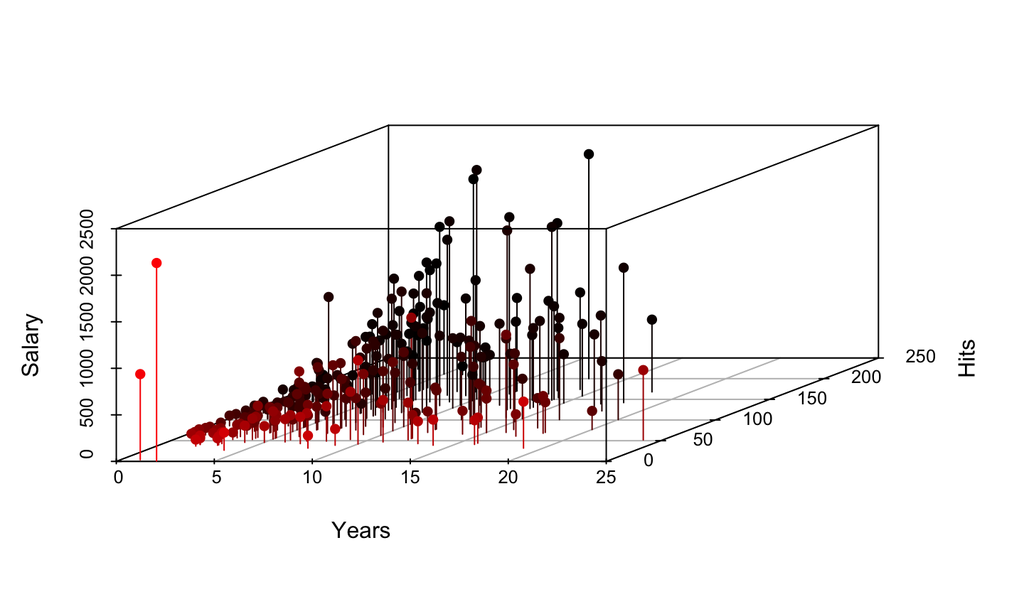

Looks like a good setting for . . . regression.

## We get: predictions

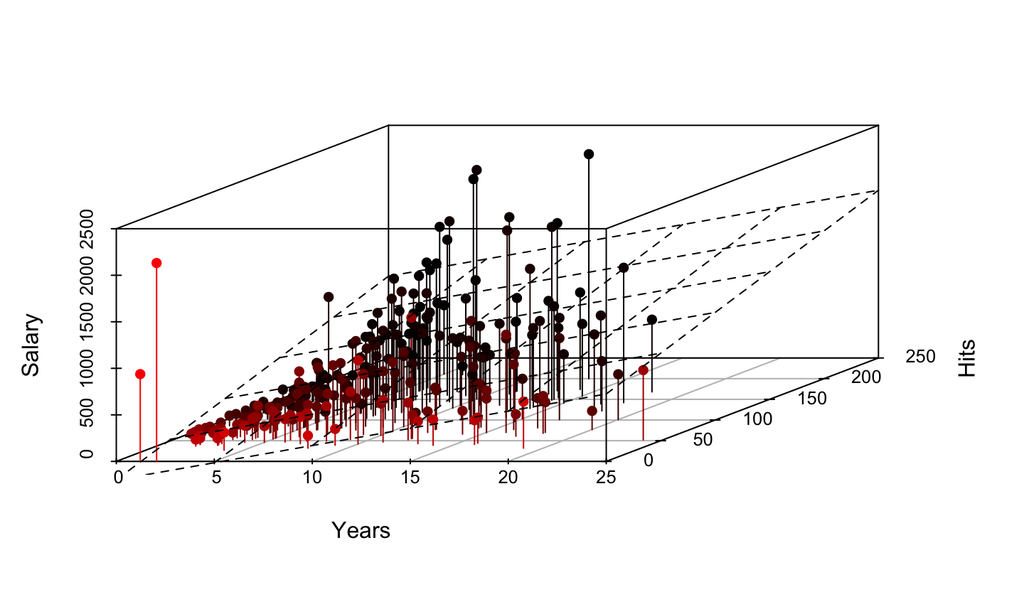

## We get: predictions

\[ MSE_{train} = \frac{1}{n}RSS \]

```r
mean(m1$res^2)
```

```
## [1] 132477.9
```

(Or better, use \(CV_{(k)}\))

## We get: a probability model

OLS regression:

\[ P(Y = y \, | \, X = x) = N(\beta_0 + \beta_1x, \sigma^2) \]

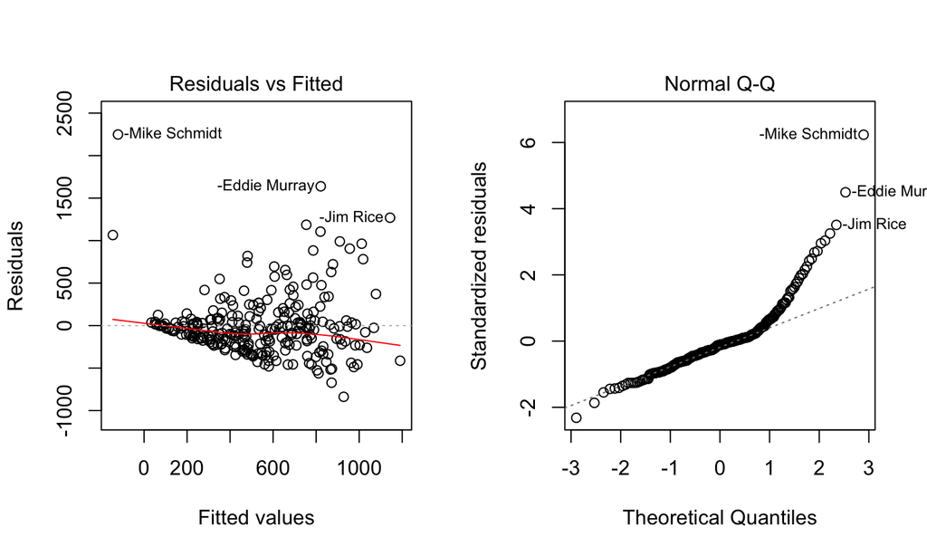

## Quick fix?

```r
Hitters$logSalary <- log(Hitters$Salary)
m2 <- lm(logSalary ~ Years + Hits, data = Hitters)
```

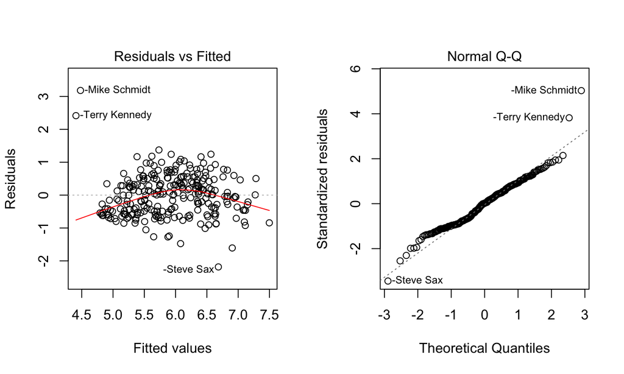

## We get: description

```r
summary(m2)$coef
```

```
##                Estimate  Std. Error   t value      Pr(>|t|)
## (Intercept) 4.275128697 0.118395330 36.108930 2.717617e-103
## Years       0.098162730 0.008280464 11.854737  3.324697e-26
## Hits        0.008665097 0.000879625  9.850899  1.163842e-19
```

- An *increase* in `Years` is associated with an *increase* in Salary, on average.
- An *increase* in `Hits` is associated with an *increase* in Salary, on average.

How can we figure out which one is more important?

## Regression Trees

**Regression Tree**: a method to predict a continuous response, \(Y\), using a series of \(p\) predictors, \(X\), by recursive binary splitting to minimize RSS.

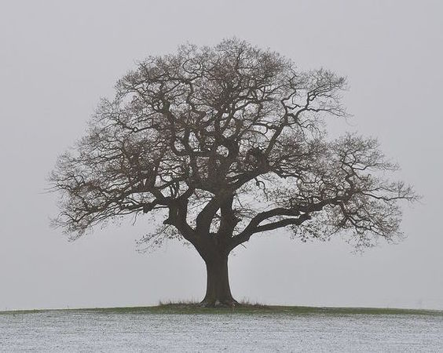

**Regression Tree**: a method to predict a continuous response, \(Y\), using a series of \(p\) predictors, \(X\), by recursive binary splitting to minimize RSS.

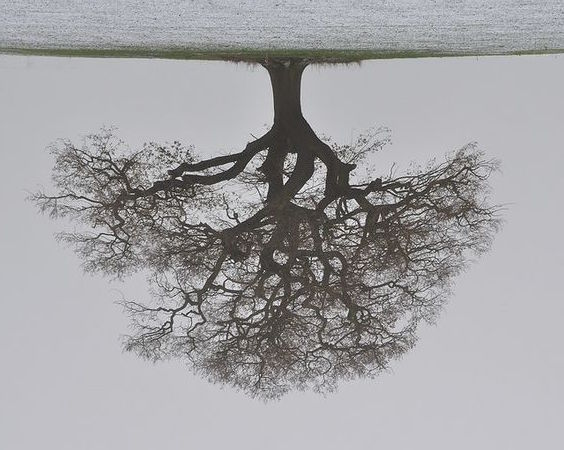

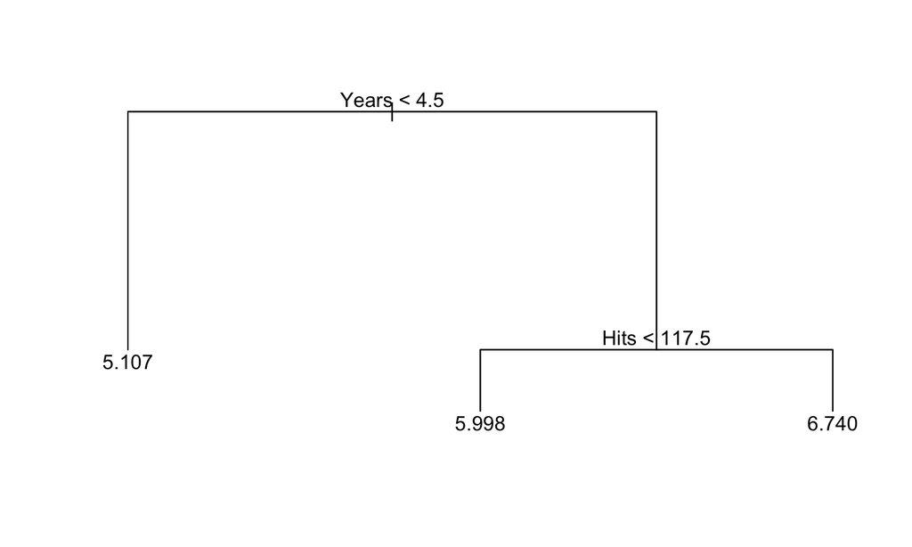

## Interpretation

- `Years` is the most important factor in contributing to salary, with less-experienced players earning less.
- Given a player is less-experienced, `Hits` has little impact on `Salary`.
- Given a player is more experienced, those with more `Hits` have a higher `Salary`.

**Practice #1**: Draw the predictor space corresponding to the following tree.

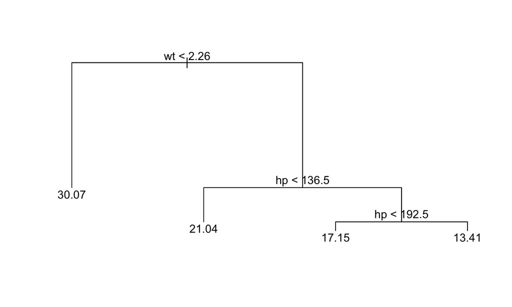

What would you expect the signs the regression slopes to be?

```
##                Estimate Std. Error   t value     Pr(>|t|)
## (Intercept) 37.22727012 1.59878754 23.284689 2.565459e-20
## hp          -0.03177295 0.00902971 -3.518712 1.451229e-03
## wt          -3.87783074 0.63273349 -6.128695 1.119647e-06
```

## Practice #2

## The Algorithm

1. Use RBS to grow a large tree on full data, stopping when every leaf has a small number of obs.
2. Apply cost-complexity pruning to obtain a best subtree for many values of \(\alpha\).
3. Use k-fold CV to choose \(\alpha\). For each fold:
   - Repeat (1) and (2) on training data.
   - Compute the test MSE on all subtrees (one test MSE per \(\alpha\)). Average the test MSEs for each \(\alpha\) and choose \(\alpha\) that minimizes.
4. Use that \(\alpha\) to select your best subtree in (2)

## Classification Trees

## Ex. MLB

```r
names(Hitters)
```

```
##  [1] "AtBat"     "Hits"      "HmRun"     "Runs"      "RBI"
##  [6] "Walks"     "Years"     "CAtBat"    "CHits"     "CHmRun"
## [11] "CRuns"     "CRBI"      "CWalks"    "League"    "Division"
## [16] "PutOuts"   "Assists"   "Errors"    "Salary"    "NewLeague"
## [21] "logSalary"
```

Can we predict the league that a player is in based on his other variables?

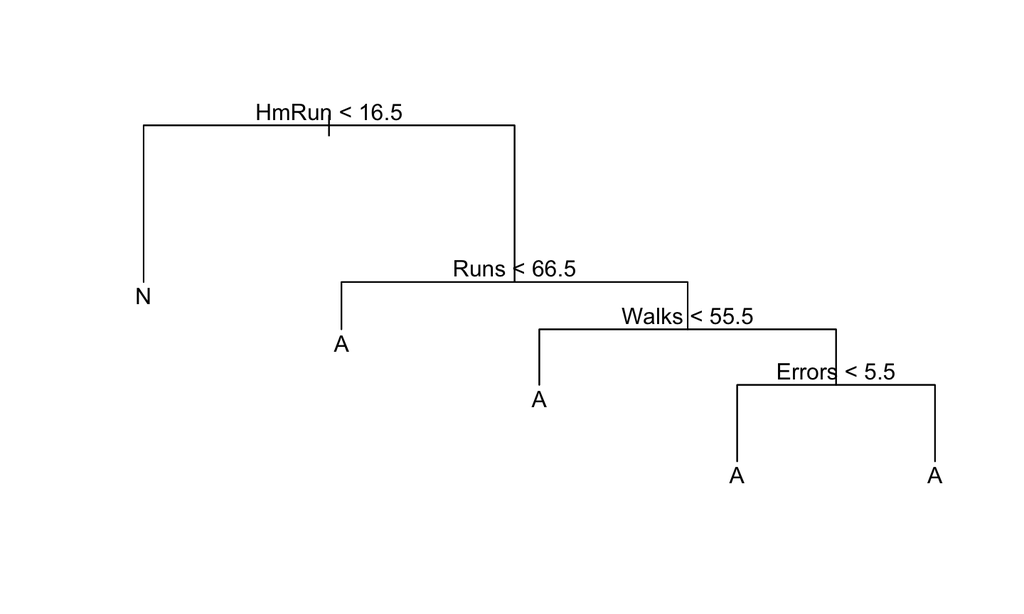